# TD2024Trabajo02

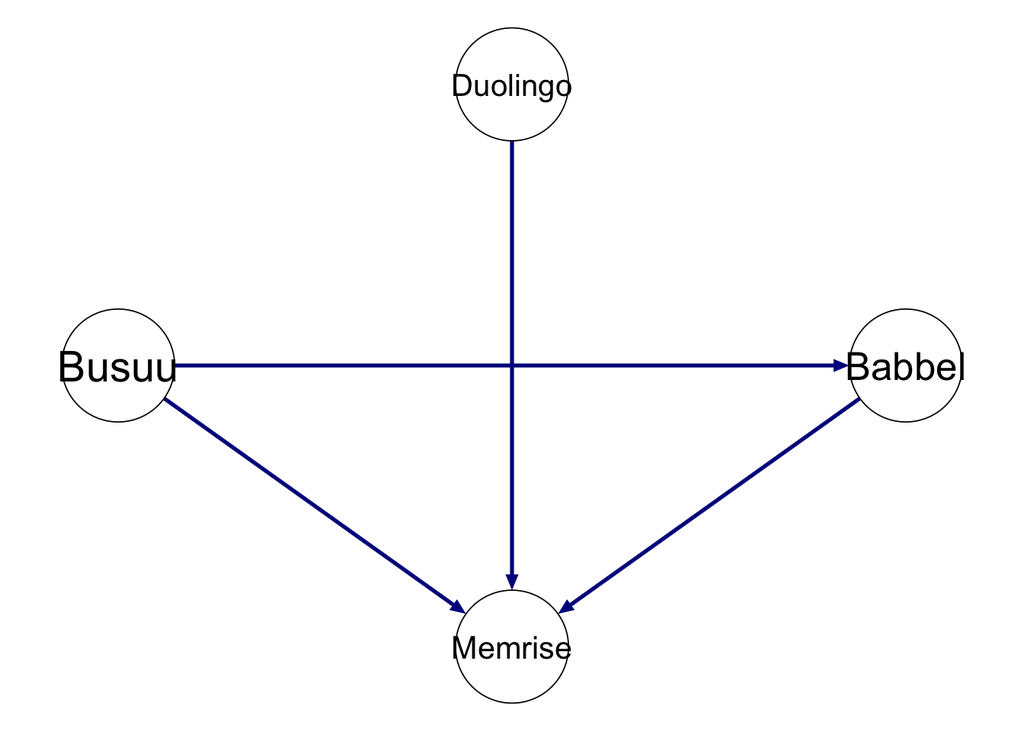

```r
# Personalizzazione del grafico
library(qgraph)
qgraph(
  electre_1$relacion.dominante,
  layout = "circle",
  vsize = 12,
  esize = 3,
  edge.color = "darkblue",
  labels = rownames(electre_1$relacion.dominante),
  label.cex = 1.4,
  directed = TRUE
)
```

Memrise es claramente la alternativa menos favorable, Dominado por todas las demás opciones. Lo omitimos en el siguiente gráfico bajando el nivel de aplha a 0,5.

```r
# alpha a 0.5
electre_reducido = multicriterio.metodoELECTRE_I(Xmatrizdecision,
                                                 pesos.criterios = pesos,
                                                 nivel.concordancia.minimo.alpha = 0.5,
                                                 no.se.compensan =c(Inf, Inf, Inf, Inf, Inf) ,
                                                 que.alternativas = c(1,2,4))
electre_reducido
```

```
## $datos
##                 Costo (€) Idiomas Método Reseñas Características
## Duolingo        0.1430615    37.0   4.50    4.70             3.0
## Babbel          0.1669449    14.0   4.80    4.60             5.0
## Busuu           0.1715266    14.0   4.60    4.60             5.0
## pesos.criterios 0.3000000     0.2   0.25    0.15             0.1
## no.se.compensan       Inf     Inf    Inf     Inf             Inf
##
## $alpha
## [1] 0.5
##
## $Imas
## , , Costo (€)
##
##          Duolingo Babbel Busuu
## Duolingo    FALSE  FALSE FALSE
## Babbel       TRUE  FALSE FALSE
## Busuu        TRUE   TRUE FALSE
##
## , , Idiomas
##
##          Duolingo Babbel Busuu
## Duolingo    FALSE   TRUE  TRUE
## Babbel      FALSE  FALSE FALSE
## Busuu       FALSE  FALSE FALSE
##
## , , Método
##
##          Duolingo Babbel Busuu
## Duolingo    FALSE  FALSE FALSE
## Babbel       TRUE  FALSE  TRUE
## Busuu        TRUE  FALSE FALSE
##
## , , Reseñas
##
##          Duolingo Babbel Busuu
## Duolingo    FALSE   TRUE  TRUE
## Babbel      FALSE  FALSE FALSE
## Busuu       FALSE  FALSE FALSE
##
```

[output cut: 100 more lines]

```
## $test.discordancia
##          Duolingo Babbel Busuu
## Duolingo     TRUE   TRUE  TRUE
## Babbel       TRUE   TRUE  TRUE
## Busuu        TRUE   TRUE  TRUE
##
## $relacion.dominante
##          Duolingo Babbel Busuu
## Duolingo    FALSE  FALSE FALSE
## Babbel       TRUE  FALSE FALSE
## Busuu        TRUE   TRUE FALSE
##
## $nucleo_aprox
## Busuu
##     3
```

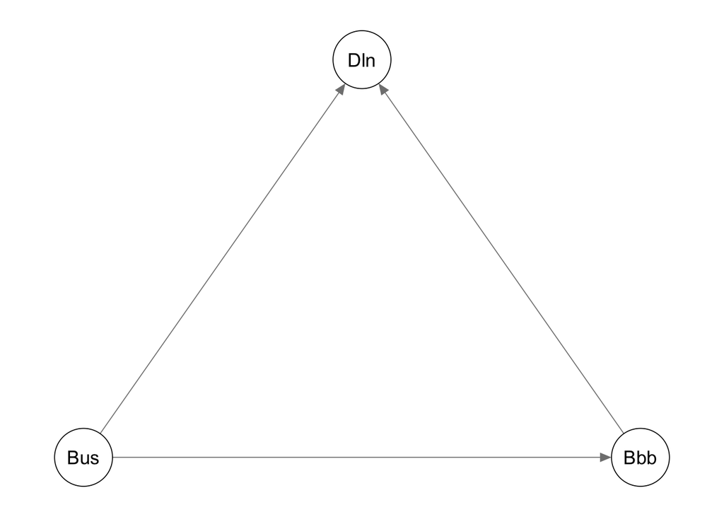

```r
qgraph::qgraph(electre_reducido$relacion.dominante)
```

Busuu muestra un comportamiento dominante respecto a las otras alternativas, mientras que Duolingo es la alternativa más débil en este contexto. Babbel está en una posición intermedia, dominada por Busuu pero dominante en comparación con Duolingo.